# Homework 6

Marko Danchak

2026-01-27

## Instructions

Answer the following questions and/or complete the exercises in RMarkdown. Please embed all of your code and push the final work to your repository. Your report should be organized, clean, and run free from errors. Remember, you must remove the `#` for any included code chunks to run.

## Load the tidyverse

```r
library("tidyverse")
library("janitor")
```

## Data

For this assignment, we will use data from a study on vertebrate community composition and impacts from defaunation in [Gabon, Africa](https://en.wikipedia.org/wiki/Gabon). One thing to notice is that the data include 24 separate transects. Each transect represents a path through different forest management areas.

Reference: Koerner SE, Poulsen JR, Blanchard EJ, Okouyi J, Clark CJ. Vertebrate community composition and diversity declines along a defaunation gradient radiating from rural villages in Gabon. *Journal of Applied Ecology*. 2016. A description of the variables is included inside the data folder.

**1. Load `IvindoData_DryadVersion.csv` and store it as a new object called `gabon`.**

```r
getwd()
```

```
## [1] "/Users/markodanchak/Downloads/datascibiol-master 3/lab6"
```

```r
setwd("/Users/markodanchak/Desktop")
gabon <- read_csv("IvindoData_DryadVersion.csv")
```

**2. Use one or more of the summary functions you have learned to get an idea of the structure of the data.**

```r
glimpse(gabon)
```

```
## Rows: 24
## Columns: 26
## $ TransectID              <dbl> 1, 2, 2, 3, 4, 5, 6, 7, 8, 9, 13, 14, 15, 16, …
## $ Distance                <dbl> 7.14, 17.31, 18.32, 20.85, 15.95, 17.47, 24.06…
## $ HuntCat                 <chr> "Moderate", "None", "None", "None", "None", "N…
## $ NumHouseholds           <dbl> 54, 54, 29, 29, 29, 29, 29, 54, 25, 73, 46, 56…
## $ LandUse                 <chr> "Park", "Park", "Park", "Logging", "Park", "Pa…
## $ Veg_Rich                <dbl> 16.67, 15.75, 16.88, 12.44, 17.13, 16.50, 14.7…
## $ Veg_Stems               <dbl> 31.20, 37.44, 32.33, 29.39, 36.00, 29.22, 31.2…
## $ Veg_liana               <dbl> 5.78, 13.25, 4.75, 9.78, 13.25, 12.88, 8.38, 8…
## $ Veg_DBH                 <dbl> 49.57, 34.59, 42.82, 36.62, 41.52, 44.07, 51.2…
## $ Veg_Canopy              <dbl> 3.78, 3.75, 3.43, 3.75, 3.88, 2.50, 4.00, 4.00…
## $ Veg_Understory          <dbl> 2.89, 3.88, 3.00, 2.75, 3.25, 3.00, 2.38, 2.71…
## $ RA_Apes                 <dbl> 1.87, 0.00, 4.49, 12.93, 0.00, 2.48, 3.78, 6.1…
## $ RA_Birds                <dbl> 52.66, 52.17, 37.44, 59.29, 52.62, 38.64, 42.6…
## $ RA_Elephant             <dbl> 0.00, 0.86, 1.33, 0.56, 1.00, 0.00, 1.11, 0.43…
## $ RA_Monkeys              <dbl> 38.59, 28.53, 41.82, 19.85, 41.34, 43.29, 46.2…
## $ RA_Rodent               <dbl> 4.22, 6.04, 1.06, 3.66, 2.52, 1.83, 3.10, 1.26…
## $ RA_Ungulate             <dbl> 2.66, 12.41, 13.86, 3.71, 2.53, 13.75, 3.10, 8…
## $ Rich_AllSpecies         <dbl> 22, 20, 22, 19, 20, 22, 23, 19, 19, 19, 21, 22…
## $ Evenness_AllSpecies     <dbl> 0.793, 0.773, 0.740, 0.681, 0.811, 0.786, 0.81…
## $ Diversity_AllSpecies    <dbl> 2.452, 2.314, 2.288, 2.006, 2.431, 2.429, 2.56…
## $ Rich_BirdSpecies        <dbl> 11, 10, 11, 8, 8, 10, 11, 11, 11, 9, 11, 11, 1…
## $ Evenness_BirdSpecies    <dbl> 0.732, 0.704, 0.688, 0.559, 0.799, 0.771, 0.80…
## $ Diversity_BirdSpecies   <dbl> 1.756, 1.620, 1.649, 1.162, 1.660, 1.775, 1.92…
## $ Rich_MammalSpecies      <dbl> 11, 10, 11, 11, 12, 12, 12, 8, 8, 10, 10, 11, …
## $ Evenness_MammalSpecies  <dbl> 0.736, 0.705, 0.650, 0.619, 0.736, 0.694, 0.77…
## $ Diversity_MammalSpecies <dbl> 1.764, 1.624, 1.558, 1.484, 1.829, 1.725, 1.92…
```

```r
str(gabon)
```

```
## spc_tbl_ [24 × 26] (S3: spec_tbl_df/tbl_df/tbl/data.frame)
##  $ TransectID             : num [1:24] 1 2 2 3 4 5 6 7 8 9 ...
##  $ Distance               : num [1:24] 7.14 17.31 18.32 20.85 15.95 ...
##  $ HuntCat                : chr [1:24] "Moderate" "None" "None" "None" ...
##  $ NumHouseholds          : num [1:24] 54 54 29 29 29 29 29 54 25 73 ...
##  $ LandUse                : chr [1:24] "Park" "Park" "Park" "Logging" ...
##  $ Veg_Rich               : num [1:24] 16.7 15.8 16.9 12.4 17.1 ...
##  $ Veg_Stems              : num [1:24] 31.2 37.4 32.3 29.4 36 ...
##  $ Veg_liana              : num [1:24] 5.78 13.25 4.75 9.78 13.25 ...
##  $ Veg_DBH                : num [1:24] 49.6 34.6 42.8 36.6 41.5 ...
##  $ Veg_Canopy             : num [1:24] 3.78 3.75 3.43 3.75 3.88 2.5 4 4 3 3.25 ...
##  $ Veg_Understory         : num [1:24] 2.89 3.88 3 2.75 3.25 3 2.38 2.71 3.25 3.13 ...
##  $ RA_Apes                : num [1:24] 1.87 0 4.49 12.93 0 ...
##  $ RA_Birds               : num [1:24] 52.7 52.2 37.4 59.3 52.6 ...
##  $ RA_Elephant            : num [1:24] 0 0.86 1.33 0.56 1 0 1.11 0.43 2.2 0 ...
##  $ RA_Monkeys             : num [1:24] 38.6 28.5 41.8 19.9 41.3 ...
##  $ RA_Rodent              : num [1:24] 4.22 6.04 1.06 3.66 2.52 1.83 3.1 1.26 4.37 6.31 ...
##  $ RA_Ungulate            : num [1:24] 2.66 12.41 13.86 3.71 2.53 ...
##  $ Rich_AllSpecies        : num [1:24] 22 20 22 19 20 22 23 19 19 19 ...
##  $ Evenness_AllSpecies    : num [1:24] 0.793 0.773 0.74 0.681 0.811 0.786 0.818 0.757 0.773 0.668 ...
##  $ Diversity_AllSpecies   : num [1:24] 2.45 2.31 2.29 2.01 2.43 ...
##  $ Rich_BirdSpecies       : num [1:24] 11 10 11 8 8 10 11 11 11 9 ...
##  $ Evenness_BirdSpecies   : num [1:24] 0.732 0.704 0.688 0.559 0.799 0.771 0.801 0.687 0.784 0.573 ...
##  $ Diversity_BirdSpecies  : num [1:24] 1.76 1.62 1.65 1.16 1.66 ...
##  $ Rich_MammalSpecies     : num [1:24] 11 10 11 11 12 12 12 8 8 10 ...
##  $ Evenness_MammalSpecies : num [1:24] 0.736 0.705 0.65 0.619 0.736 0.694 0.776 0.79 0.821 0.783 ...
##  $ Diversity_MammalSpecies: num [1:24] 1.76 1.62 1.56 1.48 1.83 ...
##  - attr(*, "spec")=
##   .. cols(
##   ..   TransectID = col_double(),
##   ..   Distance = col_double(),
##   ..   HuntCat = col_character(),
##   ..   NumHouseholds = col_double(),
##   ..   LandUse = col_character(),
##   ..   Veg_Rich = col_double(),
##   ..   Veg_Stems = col_double(),
##   ..   Veg_liana = col_double(),
##   ..   Veg_DBH = col_double(),
##   ..   Veg_Canopy = col_double(),
##   ..   Veg_Understory = col_double(),
##   ..   RA_Apes = col_double(),
##   ..   RA_Birds = col_double(),
##   ..   RA_Elephant = col_double(),
##   ..   RA_Monkeys = col_double(),
##   ..   RA_Rodent = col_double(),
##   ..   RA_Ungulate = col_double(),
##   ..   Rich_AllSpecies = col_double(),
##   ..   Evenness_AllSpecies = col_double(),
##   ..   Diversity_AllSpecies = col_double(),
##   ..   Rich_BirdSpecies = col_double(),
##   ..   Evenness_BirdSpecies = col_double(),
##   ..   Diversity_BirdSpecies = col_double(),
##   ..   Rich_MammalSpecies = col_double(),
##   ..   Evenness_MammalSpecies = col_double(),
##   ..   Diversity_MammalSpecies = col_double()
##   .. )
##  - attr(*, "problems")=<externalptr>
```

**3. Clean the data as necessary following the conventions from lab 6.**

```r
gabon <- gabon %>%
  clean_names()
```

**4. Use `mutate()` Change the variables `HuntCat`, `LandUse`, and `TransectID` to factors. Be sure to store the output as a new dataframe and use it for the remaining questions.**

```r
gabon <- gabon %>%
  mutate(HuntCat=factor(hunt_cat),
         LandUse=factor(land_use),
         TransectID= factor(transect_id))
```

**5. Make a plot that shows the number of transects for each land use type.**

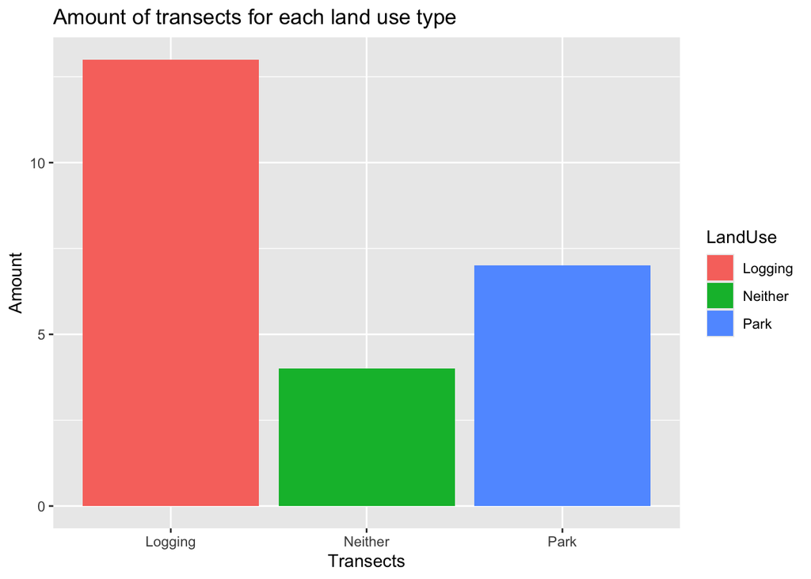

```r
gabon %>%
  ggplot(mapping=aes(x= LandUse)) +
  geom_bar(mapping=aes(fill=LandUse))+
  labs (title= "Amount of transects for each land use type", x="Transects", y= "Amount")
```

**6. How does vegetation richness compare among land use types?**

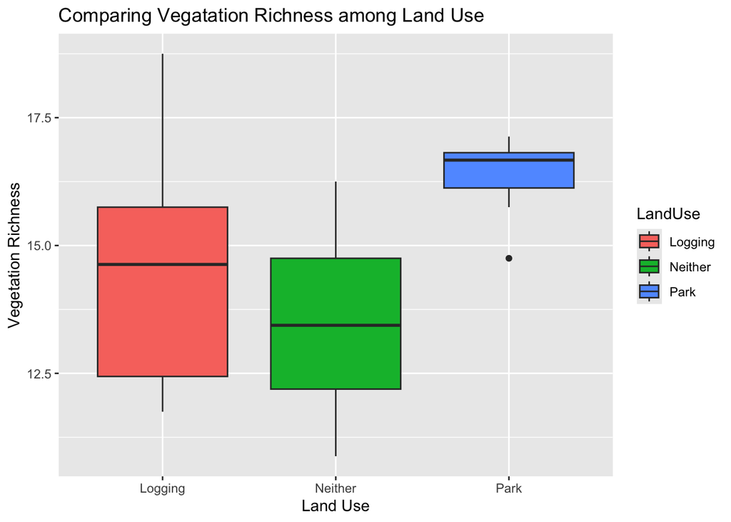

```r
gabon %>%
  ggplot(mapping=aes(x= LandUse, y= veg_rich)) +
  scale_x_discrete(na.translate= FALSE) +
  geom_boxplot(mapping = aes(fill = LandUse)) +
  labs(title = "Comparing Vegatation Richness among Land Use", x= "Land Use", y= "Vegetation Richness")
```

**7. For which land use type (national parks, logging, or neither) is average all species diversity the greatest?**

```r
gabon %>%
  select(LandUse, diversity_all_species) %>%
  arrange(desc(diversity_all_species))
```

```
## # A tibble: 24 × 2
##    LandUse diversity_all_species
##    <fct>                   <dbl>
##  1 Park                     2.57
##  2 Park                     2.50
##  3 Park                     2.45
##  4 Neither                  2.45
##  5 Neither                  2.45
##  6 Park                     2.43
##  7 Park                     2.43
##  8 Logging                  2.38
##  9 Logging                  2.37
## 10 Logging                  2.37
## # ℹ 14 more rows
```

**8. Is there a relationship between vegetation richness and mammal species richness?**

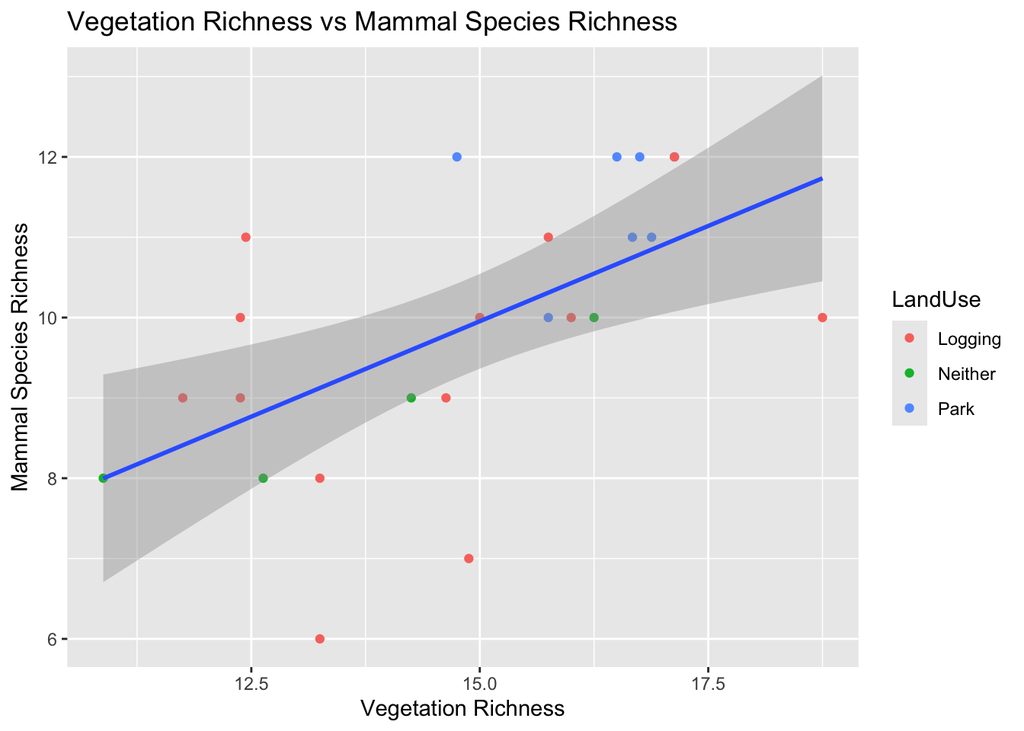

```r
gabon %>%
  ggplot (mapping = aes(x= veg_rich, y= rich_mammal_species)) +
  geom_point(mapping= aes(color= LandUse), na.rm= TRUE) +
  geom_smooth(method = lm, se = TRUE) +
  labs(title= "Vegetation Richness vs Mammal Species Richness", x= "Vegetation Richness", y="Mammal Species Richness" )
```

**9. Use `filter` to find all transects that have greater than 15 tree species or a breast height diameter between 50 and 60cm.**

```r
gabon %>%
  filter(veg_rich > 15 | veg_dbh >= 50, veg_dbh <= 60)
```

```
## # A tibble: 13 × 29
##    transect_id distance hunt_cat num_households land_use veg_rich veg_stems
##          <dbl>    <dbl> <chr>             <dbl> <chr>       <dbl>     <dbl>
##  1           1     7.14 Moderate             54 Park         16.7      31.2
##  2           2    17.3  None                 54 Park         15.8      37.4
##  3           2    18.3  None                 29 Park         16.9      32.3
##  4           4    16.0  None                 29 Park         17.1      36
##  5           5    17.5  None                 29 Park         16.5      29.2
##  6           6    24.1  None                 29 Park         14.8      31.2
##  7          14     8.23 Moderate             56 Logging      15.8      30.2
##  8          15     2.7  High                 46 Neither      10.9      25.4
##  9          17     3.83 High                 19 Neither      14.2      32.6
## 10          21     5.14 High                 24 Neither      16.2      34.9
## 11          22     5.33 High                 13 Logging      17.1      41.6
## 12          24    26.8  None                 29 Park         16.8      37.3
## 13          26    11.2  Moderate             73 Logging      18.8      39.1
## # ℹ 22 more variables: veg_liana <dbl>, veg_dbh <dbl>, veg_canopy <dbl>,
## #   veg_understory <dbl>, ra_apes <dbl>, ra_birds <dbl>, ra_elephant <dbl>,
## #   ra_monkeys <dbl>, ra_rodent <dbl>, ra_ungulate <dbl>,
## #   rich_all_species <dbl>, evenness_all_species <dbl>,
## #   diversity_all_species <dbl>, rich_bird_species <dbl>,
## #   evenness_bird_species <dbl>, diversity_bird_species <dbl>,
## #   rich_mammal_species <dbl>, evenness_mammal_species <dbl>, …
```

**10.Which transects and land use types have more than 10 tree species and 10 mammal species? Use `arrange()` to sort by the number of tree species.**

```r
gabon %>%
  filter(veg_rich > 10, rich_mammal_species > 10) %>%
  select(TransectID, LandUse, HuntCat, veg_rich, rich_mammal_species) %>%
  arrange(desc(veg_rich))
```

```
## # A tibble: 9 × 5
##   TransectID LandUse HuntCat  veg_rich rich_mammal_species
##   <fct>      <fct>   <fct>       <dbl>               <dbl>
## 1 4          Park    None         17.1                  12
## 2 22         Logging High         17.1                  12
## 3 2          Park    None         16.9                  11
## 4 24         Park    None         16.8                  12
## 5 1          Park    Moderate     16.7                  11
## 6 5          Park    None         16.5                  12
## 7 14         Logging Moderate     15.8                  11
## 8 6          Park    None         14.8                  12
## 9 3          Logging None         12.4                  11
```

## Knit and Upload

Please knit your work as an .html file and upload to Canvas. Homework is due before the start of the next lab. No late work is accepted. Make sure to use the formatting conventions of RMarkdown to make your report neat and clean!